# Generalizability of Transcriptome Prediction - FPKM Normalized TCGA Data

Amir Asiaee

2023-10-22

# Getting Started

```r
rm(list=ls())
source("00-paths.R")
ls()
```

```
## [1] "paths"
```

Load both mRNA and miR data:

```r
f <- file.path(paths$clean, "noGBMmatchedData.Rda")
if (file.exists(f)) {
  load(f)
} else {
  load(file = file.path(paths$clean, "matchedData.Rda"))
  discard <- which(cancerType == 'GBM')
  mRNAdata <- mRNAdata[, -discard]
  miRdata <- miRdata[, -discard]
  save(mRNAdata, miRdata, file = f)
}
dim(mRNAdata)
```

```
## [1] 20289  8890
```

```r
dim(miRdata)
```

```
## [1] 1146 8890
```

```r
rm(discard, f)
gc()
```

```
##             used   (Mb) gc trigger   (Mb)  max used   (Mb)
## Ncells    561614   30.0    1195015   63.9    643711   34.4
## Vcells 191576978 1461.7  263672895 2011.7 191621641 1462.0
```

Separate TF from mRNAs that we want to predict:

```r
f <- file.path(paths$scratch, 'tfdata.Rda')
g <- file.path(paths$scratch, 'mrnaRestdata.Rda')
if (file.exists(f)) {
  load(f)
  load(g)
} else {
  htf <- read.csv(file = file.path(paths$raw, "HumanTF.csv"))
  tfSymbols <- htf$Hs.SYMBOL
  tfSymbols <- tfSymbols[!is.na(tfSymbols)]
  sum(tfSymbols %in% rownames(mRNAdata))
  tfdata <- mRNAdata[(rownames(mRNAdata) %in% tfSymbols), ]
  mRNARest <- mRNAdata[!(rownames(mRNAdata) %in% tfSymbols), ]
  save(tfdata, file = f)
  save(mRNARest, file = g)
}
dim(tfdata)
```

```
## [1]  486 8890
```

```r
dim(mRNARest)
```

```
## [1] 19803  8890
```

```r
rm(mRNAdata, f, g, tfSymbols, sampleType, htf)
gc()
```

```
##             used   (Mb) gc trigger   (Mb)  max used   (Mb)
## Ncells    561959   30.1    1195015   63.9    643711   34.4
## Vcells 191587162 1461.7  448441619 3421.4 372026804 2838.4
```

# Cross-Validation for Model Complexity Selection

## Saving Train and Test Batches for Cross Validation

Adding fold variable to each sample and saving train/test portions for the whole analysis:

```r
f <- file.path(paths$scratch, paste('train_batch_fpkm_', 1, '.Rda', sep = ''))
nfolds <- 5
if (!file.exists(f)) {
  foldsId <- rep(1:nfolds, length.out = ncol(mRNARest))
  for (k in 1:nfolds) {
    print(paste("Fold", k, "started."))
    index <- which(foldsId == k)
    f <- file.path(paths$scratch, paste('train_batch_fpkm_', k, '.Rda', sep = ''))
    g <- file.path(paths$scratch, paste('test_batch_fpkm_', k, '.Rda', sep = ''))


    tfTrain <- tfdata[,-index]; tfTest <- tfdata[,index];
    mirTrain <- miRdata[,-index]; mirTest <- miRdata[,index];
    mrnaTrain <- mRNARest[,-index]; mrnaTest <- mRNARest[,index];

    save(tfTrain, mirTrain, mrnaTrain, file = f)
    save(tfTest, mirTest, mrnaTest, file = g)
  }
}
rm(mRNARest, miRdata, tfdata)
rm(mirTest, mirTrain, mrnaTest, mrnaTrain, tfTest, tfTrain, foldsId, f, g, index, k)
gc()
```

```
##          used (Mb) gc trigger   (Mb)  max used   (Mb)
## Ncells 531712 28.4    1195015   63.9    643711   34.4
## Vcells 939941  7.2  358753296 2737.1 372026804 2838.4
```

## Variable Selection with Thresher

Variable selection:

```r
suppressMessages( library(Thresher) ) # brings along PCDimension automatically

f <- file.path(paths$scratch, paste('thresh_reap_miR_fpkm_', 5, '.Rda', sep = ''))

if (!file.exists(f)) {
  set.seed(47053)
  for (k in 1:nfolds) {
    print(paste("Fold", k, "threshing started."))
    load(file.path(paths$scratch, paste('train_batch_fpkm_', k, '.Rda', sep = '')))
    rm(mrnaTrain)

    print(paste("Thresher for TFs"))
    startTime <- Sys.time()
    Thresh <- Thresher(t(tfTrain), method = "auer.gervini",
                       scale = TRUE, agfun = agDimTwiceMean)
    Reap <- Reaper(Thresh, useLoadings = TRUE, cutoff = 0.35,
                   metric = NULL, linkage = "ward.D2", maxSampleGroups = 486)
    f <- file.path(paths$scratch, paste('thresh_reap_tf_fpkm_', k, '.Rda', sep = ''))
    save(Thresh, Reap, file = f)
    print(Sys.time() - startTime)

    print(paste("Thresher for miRs"))
    startTime <- Sys.time()
    nonzero <- apply(mirTrain, 1, function(x) sum(x != 0))
    cutoff <- 0.25 * ncol(mirTrain)
    filteredMir <- mirTrain[nonzero > cutoff, ]

    Thresh <- Thresher(t(filteredMir), method = "auer.gervini",
                       scale = TRUE, agfun = agDimTwiceMean)
    Reap <- Reaper(Thresh, useLoadings = TRUE, cutoff = 0.35,
                   metric = NULL, linkage = "ward.D2", maxSampleGroups = 486)
    f <- file.path(paths$scratch, paste('thresh_reap_miR_fpkm_', k, '.Rda', sep = ''))
    save(Thresh, Reap, file = f)
    print(Sys.time() - startTime)
  }
}
rm(f, Thresh, Reap, cutoff, nonzero, filteredMir, tfTrain, mirTrain)
gc()
```

```
##           used (Mb) gc trigger   (Mb)  max used   (Mb)
## Ncells 1227093 65.6    1973418  105.4   1973418  105.4
## Vcells 1913069 14.6  229602110 1751.8 372026804 2838.4
```

## Medoid Computation

We need to save the medoids:

```r
f <- file.path(paths$scratch, paste('medoids_mir_fpkm_', 5, '.Rda', sep = ''))

if (!file.exists(f)) {
  set.seed(41053)
  for (k in 1:nfolds) {
    print(paste("Fold", k, "mediod finding started."))
    load(file.path(paths$scratch, paste('train_batch_fpkm_', k, '.Rda', sep = '')))
    rm(mrnaTrain)

    load(file.path(paths$scratch, paste('thresh_reap_tf_fpkm_', k, '.Rda', sep = '')))
    groups <- predict(Reap@fit)
    names(groups) <- rownames(tfTrain)[Reap@keep]
    NG <- Reap@nGroups
    tfMedoid <- matrix(0, ncol(tfTrain), NG)
    colnames(tfMedoid) <- 1:ncol(tfMedoid)
    d2MeanList <- list()
    for (I in 1:NG) {
      clusterExp <- tfTrain[names(groups)[groups == I], ]
      meanZeroClusterExp <- sweep(clusterExp, 2, apply(clusterExp, 2, mean))
      d2Mean <- apply(meanZeroClusterExp, 1, function(x) {sqrt(sum(x * x))})
      medoidGene <- rownames(clusterExp)[which.min(d2Mean)]
      tfMedoid[, I] <- tfTrain[medoidGene, ]
      colnames(tfMedoid)[I] <- medoidGene
      d2MeanList[[I]] <- d2Mean
    }
    f <- file.path(paths$scratch, paste('medoids_tf_fpkm_', k, '.Rda', sep = ''))
    save(tfMedoid, file = f)
    f <- file.path(paths$scratch, paste('d2MeanList_tf_fpkm_', k, '.Rda', sep = ''))
    save(d2MeanList, file = f)

    load(file.path(paths$scratch, paste('thresh_reap_miR_fpkm_', k, '.Rda', sep = '')))
    nonzero <- apply(mirTrain, 1, function(x) sum(x != 0))
    cutoff <- 0.25 * ncol(mirTrain)
    filteredMir <- mirTrain[nonzero > cutoff, ]

    groups <- predict(Reap@fit)
    names(groups) <- rownames(filteredMir)[Reap@keep]
    NG <- Reap@nGroups
    mirMedoid <- matrix(0, ncol(filteredMir), NG)
    colnames(mirMedoid) <- 1:ncol(mirMedoid)
    d2MeanList <- list()
    for (I in 1:NG) {
      clusterExp <- filteredMir[names(groups)[groups == I], ]
      meanZeroClusterExp <- sweep(clusterExp, 2, apply(clusterExp, 2, mean))
      d2Mean <- apply(meanZeroClusterExp, 1, function(x) {sqrt(sum(x * x))})
      medoidGene <- rownames(clusterExp)[which.min(d2Mean)]
      mirMedoid[, I] <- filteredMir[medoidGene, ]
      colnames(mirMedoid)[I] <- medoidGene
      d2MeanList[[I]] <- d2Mean
    }
    f <- file.path(paths$scratch, paste('medoids_mir_fpkm_', k, '.Rda', sep = ''))
    save(mirMedoid, file = f)
    f <- file.path(paths$scratch, paste('d2MeanList_mir_fpkm_', k, '.Rda', sep = ''))
    save(d2MeanList, file = f)
  }
}
rm(f, tfMedoid, mirMedoid, groups, NG, d2MeanList, clusterExp, meanZeroClusterExp, d2Mean, medoidGene)
rm(nonzero, startTime, I, k, cutoff)
```

## Pseudo-Tissue (Cluster) Aware Linear Model

Next, we fit the linear models for each tissue after mean zeroing the outcome (this is equivalent to fit a model to all tissue and then fit the residuals of that model per tissue).

###Train First the training part:

```r
trainClusterAware <- function(X, Y, nc){
  coeffMatList <- list()
  N <- nrow(X); M <- nrow(Y); P <- ncol(X);
  res <- matrix(0, nrow = M, ncol = N)
  cat(paste("\n  Trianing with ", nc, " clusters:"))
  cat("\n    1) Clustering")
  myClust <- kmeans(X, nc, iter.max = 100, nstart = 100)
  assignment <- myClust$cluster

  cat("\n    2) Regression")
  cat("\n      Fitting OLS to clusters 1")
  for (cluster in 1:nc) {
    if(cluster %% 5 == 0) cat(paste(cluster)) else cat('.')
    coeffMat <- matrix(0, nrow = P + 1, ncol = M,
                       dimnames = list(c('(Intercept)',
                                         gsub('\\-', '.', colnames(X))),
                                         rownames(Y)))

    S <- (assignment == cluster) #Cluster Selector
    #remove constant covariates
    varCov <- apply(X[S,], 2, var) != 0
    Xs <- X[S, varCov]
    mapping <- which(varCov)
    Ys <- Y[, S]

    if (nrow(Xs) < ncol(Xs)) {
      #Not enough samples per cluster
      #Per-cluster average is our predictor
      #YcAvg is our predictions and the residuals are mean0Yc
      # pred[, S] <- matrix(rep(YcAvg, S), ncol = S)
      coeffMat[1,] <- apply(Ys, 1, mean)#YcAvg
      res[, S] <- sweep(Ys, 1, coeffMat[1,])#mean0Yc
    } else{
      tryCatch({
        mlm <- MultiLinearModel(Y ~ ., Xs, Ys)
        # pred[, S] <- t(mlm@predictions)
        # coeffMat[rownames(mlm@coefficients),] <- mlm@coefficients
        coeffMat[1,] <- mlm@coefficients[1, ]  # +1 to account for the '(Intercept)' row
        coeffMat[mapping + 1,] <- mlm@coefficients[-1, ]  # +1 to account for the '(Intercept)' row
        res[, S] <- Ys - t(mlm@predictions)
        }, error = function(e) {
          coeffMat[1,] <- apply(Ys, 1, mean)#YcAvg
          res[, S] <- sweep(Ys, 1, coeffMat[1,])#mean0Yc
      })
    }
    coeffMatList[[cluster]] <- coeffMat
  }

  r2 <- computeR2(res, Y)
  # hist(r2, breaks=123)
  cat(paste("\n      Average R2:", round(mean(r2, na.rm =T), 2)))
  rmse <- sqrt((1/N) * apply(res ^ 2, 1, sum))
  cat(paste("\n      Averge RMSE:", round(mean(rmse),2)))
  corr <- computeCor(res, Y)
  cat(paste("\n      Averge Cor:", round(mean(corr$acc),2)))

  trained <- list(coeffMatList=coeffMatList, nc=nc,
                  res=res, r2=r2, rmse=rmse, corr=corr,
                  centers=myClust$centers)
  # save(trained, file = file.path(paths$scratch, paste('trained_fpkm_', nc, '.Rda', sep = '')))

  return(trained)
}
```

Note that we do not save the whole MLM object, we just keep the coefficient matrix and the performance metrics that we keep track of: R2, RMSE, and Correlation of the prediction with outcome. We also keep the number of clusters and the cluster centers for the testing phase.

### Test

Next testing: First for each new test data we find the closest cluster center from the training and then we use the corresponding linear model for prediction. Note that R2 here is not a valid measure because it may become arbitrarily small since any predictive model trained on training data can do worse than the test data mean. So we only compute RMSE and Correlation performances.

```r
testClusterAware <- function(X, Y, model){
  centers <- model$centers
  cat(paste("\n  Testing with ", nrow(centers), " clusters:"))
  M <- nrow(Y); N <- ncol(Y); #nrow(X) == N
  D <- matrix(0, nrow = N, ncol = nrow(centers))
  for(i in 1:nrow(centers)){
    center <- centers[i, ]
    D[,i] <- apply(X, 1, function(x) sum((x - center)^2))
  }
  C <- apply(D, 1, which.min)

  res <- matrix(0, nrow = M, ncol = N)
  aX <- cbind(rep(1, nrow(X)), X) #augmented X
  for(i in 1:nrow(centers)){
    res[, C==i] <- Y[,C==i] - t(aX[C==i, ] %*% model$coeffMatList[[i]])
  }
  rmse <- sqrt((1/N) * apply(res ^ 2, 1, sum))
  cat(paste("\n    Averge RMSE:", round(mean(rmse),2)))
  corr <- computeCor(res, Y)
  # cat(paste("\n    Averge Cor:", round(mean(corr$acc),2)))
  cat(paste("\n    Averge Cor:", round((corr$acc),2)))


  tested <- list(res=res, rmse=rmse, corr=corr)
  # save(tested, file = file.path(paths$scratch, paste('tested_fpkm_', model$nc, '.Rda', sep = '')))

  return(tested)
}
```

### Cross-Validation

Finally, we run the model:

```r
nClusters <- c(1, 5, 10, 15, 20, 25, 30, 35)

f <- file.path(paths$scratch, paste('fold_', 5, '_kmeans_fpkm_',
                                          35, '.Rda', sep = ''))
if (!file.exists(f)) {
  set.seed(41053)
  cvTable <- matrix(0, nrow = nfolds, ncol = length(nClusters))

  for (k in 1:nfolds) {
    cat(paste("\nFold ", k, ": ", sep = ''))
    # Load Training Samples (tfTrain, mirTrain, mrnaTrain)
    load(file.path(paths$scratch, paste('train_batch_fpkm_', k, '.Rda', sep = '')))
    rm(tfTrain, mirTrain)
    ## Global mean removal for Data Sharing
    Yavg <- apply(mrnaTrain, 1, mean)
    mean0Y <- sweep(mrnaTrain, 1, Yavg)
    ## Load Selected Features
    load(file.path(paths$scratch, paste('medoids_tf_fpkm_', k, '.Rda', sep = '')))
    load(file.path(paths$scratch, paste('medoids_mir_fpkm_', k, '.Rda', sep = '')))
    X <- cbind(tfMedoid, mirMedoid)
    cat(paste("Dimensions of X is", paste(dim(X), collapse = '*')))
    # Load Test Samples (tfTest, mirTest, mrnaTest)
    load(file.path(paths$scratch, paste('test_batch_fpkm_', k, '.Rda', sep = '')))
    ## Prepare Test Features (match with the selected features of training set)
    tfTestMedoid <- t(tfTest[colnames(tfMedoid), ])
    mirTestMedoid <- t(mirTest[colnames(mirMedoid),])
    Xt <- cbind(tfTestMedoid, mirTestMedoid)
    mean0Yt <- sweep(mrnaTest, 1, Yavg)

    cnt <- 0
    for(nc in nClusters){
      cnt <- cnt + 1
      #Train
      learned <- trainClusterAware(X, mean0Y, nc)
      #Test
      tested <- testClusterAware(Xt, mean0Yt, learned)
      #Save
      cvTable[k, cnt] <- mean(tested$rmse)
      f <- file.path(paths$scratch, paste('fold_', k, '_kmeans_fpkm_',
                                          nc, '.Rda', sep = ''))
      cat(paste("\nSaving results of", nc, "clusters for fold", k))
      save(learned, tested, file = f)
    }
  }
}

rm(f, cvTable, tested, learned, cnt, mean0Yt, Xt, mirTestMedoid, tfTestMedoid, X, mean0Y, Yavg)
rm(nc, k, cnt)
gc()
```

```
##           used (Mb) gc trigger   (Mb)  max used   (Mb)
## Ncells 1520181 81.2    2977447  159.1   1973418  105.4
## Vcells 2422239 18.5  183681688 1401.4 372026804 2838.4
```

So the best test performance corresponds to 15 clusters. Let’s take a look at the train and test results.

```r
g <- file.path(paths$scratch, 'cvTables_fpkm.Rda')
if (file.exists(g)) {
  load(g)
} else{
  cvR2Trn <- cvCorrTst <- cvCorrTrn <- cvRmseTst <- cvRmseTrn <- matrix(0, nrow = nfolds, ncol = length(nClusters))
  colnames(cvR2Trn) <- colnames(cvCorrTst) <- colnames(cvRmseTst) <- paste("nc", nClusters, sep = '-')

  cnt <- 0
  for(nc in nClusters){
    cnt <- cnt + 1
    cat(paste("\nNumber of clusters:", nc, "Folds"))
    for (k in 1:nfolds) {
      cat(paste(" ", k))
      f <- file.path(paths$scratch, paste('fold_', k, '_kmeans_fpkm_',
                                            nc, '.Rda', sep = ''))
      load(file = f)
      # print(summary(learned$r2))
      # hist(learned$r2, breaks=234,
      #      main=paste("Number of Clusters=", nc, ",Fold=", k,
      #                 ",Average R2=", round(stat['Mean'],2)),
      #      xlab = "R2")
      cvR2Trn[k, cnt] <- mean(learned$r2, na.rm=TRUE)
      cvRmseTst[k, cnt] <- mean(tested$rmse)
      cvRmseTrn[k, cnt] <- mean(learned$rmse)
      cvCorrTst[k, cnt] <- mean(tested$corr$acc)
      cvCorrTrn[k, cnt] <- mean(learned$corr$acc)
    }
  }
  save(cvR2Trn, cvCorrTst, cvCorrTrn, cvRmseTst, cvRmseTrn, file=g)
}

print("R2 during training:")
```

```
## [1] "R2 during training:"
```

```r
print(cvR2Trn)
```

```
##           nc-1      nc-5     nc-10     nc-15     nc-20     nc-25     nc-30
## [1,] 0.4336557 0.5284865 0.5814561 0.6216500 0.6452693 0.6688098 0.6904920
## [2,] 0.4443167 0.5400823 0.5947768 0.6305183 0.6596609 0.6794411 0.6997407
## [3,] 0.4398945 0.5400960 0.5864459 0.6272390 0.6552241 0.6766705 0.6995949
## [4,] 0.4377495 0.5399665 0.5870177 0.6243652 0.6486055 0.6727302 0.6959844
## [5,] 0.4359925 0.5232699 0.5854531 0.6299394 0.6591002 0.6813679 0.7041996
##          nc-35
## [1,] 0.6949208
## [2,] 0.7165514
## [3,] 0.7178792
## [4,] 0.7155508
## [5,] 0.7155508
```

```r
print(paste("Average train R2:", paste(round(apply(cvR2Trn, 2, mean),3) , collapse = ',')))
```

```
## [1] "Average train R2: 0.438,0.534,0.587,0.627,0.654,0.676,0.698,0.712"
```

```r
print("RMSE for training:")
```

```
## [1] "RMSE for training:"
```

```r
print(cvRmseTst)
```

```
##           nc-1      nc-5     nc-10     nc-15     nc-20     nc-25     nc-30
## [1,] 0.7443055 0.6900268 0.6715187 0.6660290 0.9046711 0.9286811 0.9514637
## [2,] 0.7348421 0.6786329 0.6625007 0.6709841 0.6826956 0.7027077 0.7239477
## [3,] 0.7328018 0.6721859 0.6635376 0.6550901 0.6596124 0.6782356 0.7010815
## [4,] 0.7346477 0.6695398 0.6629171 0.6601925 0.6810776 0.6878151 0.7193886
## [5,] 0.7401842 0.6941663 0.6715683 0.6621696 0.6703904 0.7436731 0.7806088
##          nc-35
## [1,] 1.2382749
## [2,] 0.7570659
## [3,] 0.7302924
## [4,] 0.7262559
## [5,] 0.7262559
```

```r
print(paste("Best number of clusters according to RMSE:", colnames(cvRmseTst)[which.min(apply(cvRmseTst, 2, mean))]))
```

```
## [1] "Best number of clusters according to RMSE: nc-15"
```

```r
print(paste("Average test RMSE:", paste(round(apply(cvRmseTst, 2, mean),3), collapse = ',')))
```

```
## [1] "Average test RMSE: 0.737,0.681,0.666,0.663,0.72,0.748,0.775,0.836"
```

```r
print("Corr for training:")
```

```
## [1] "Corr for training:"
```

```r
print(cvCorrTst)
```

```
##           nc-1      nc-5     nc-10     nc-15     nc-20     nc-25     nc-30
## [1,] 0.9252134 0.9402616 0.9427359 0.9428874 0.9101146 0.9232945 0.9162753
## [2,] 0.9314245 0.9420795 0.9424835 0.9413220 0.9378377 0.9366763 0.9346564
## [3,] 0.9269303 0.9416250 0.9406656 0.9405141 0.9400596 0.9385447 0.9355148
## [4,] 0.9304651 0.9524819 0.9555623 0.9573297 0.9482907 0.9501086 0.9479877
## [5,] 0.9276877 0.9395041 0.9416250 0.9450083 0.9436954 0.9384437 0.9341514
##          nc-35
## [1,] 0.8741100
## [2,] 0.9373832
## [3,] 0.9327375
## [4,] 0.9501591
## [5,] 0.9501591
```

```r
print(paste("Best number of clusters according to Correlation:", colnames(cvCorrTst)[which.max(apply(cvCorrTst, 2, mean))]))
```

```
## [1] "Best number of clusters according to Correlation: nc-15"
```

```r
print(paste("Average test Corr:", paste(round(apply(cvCorrTst, 2, mean),4), collapse = ',')))
```

```
## [1] "Average test Corr: 0.9283,0.9432,0.9446,0.9454,0.936,0.9374,0.9337,0.9289"
```

```r
rm(cnt, f)
```

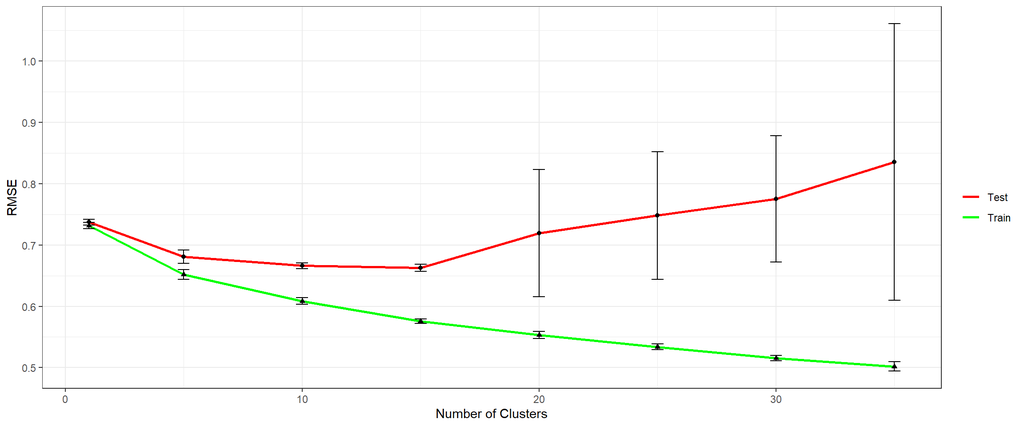

```r
library(ggplot2)

plot.cv <- function(cvtrain, cvtest, ytext){
  yt <- colMeans(cvtest)
  et <- apply(cvtest, 2, sd)

  yn <- colMeans(cvtrain)
  en <- apply(cvtrain, 2, sd)

  toplot <- data.frame(yt = yt,et = et,yn = yn,en = en,nc = nClusters)

  ggplot(toplot) +
    geom_line(aes(x = nc, y = yt, col = "Test"), size = 1) +
    geom_point(aes(x = nc, y = yt, shape = 'a'), show.legend = FALSE) +
    geom_line(aes(x = nc, y = yn, col = "Train"), size = 1) +
    geom_point(aes(x = nc, y = yn, shape = 'c'), show.legend = FALSE) +
    geom_errorbar(aes(x = nc,ymin = yt - et,ymax = yt + et), width = 0.5) +
    geom_errorbar(aes(x = nc,ymin = yn - en,ymax = yn + en), width = 0.5) +
    theme_bw() + xlab("Number of Clusters") + ylab(ytext) +
    scale_color_manual(values = c("red", "green"), name = "")
}

load(file.path(paths$scratch, 'cvTables_fpkm.Rda'))

plot.cv(cvRmseTrn, cvRmseTst, "RMSE")
```

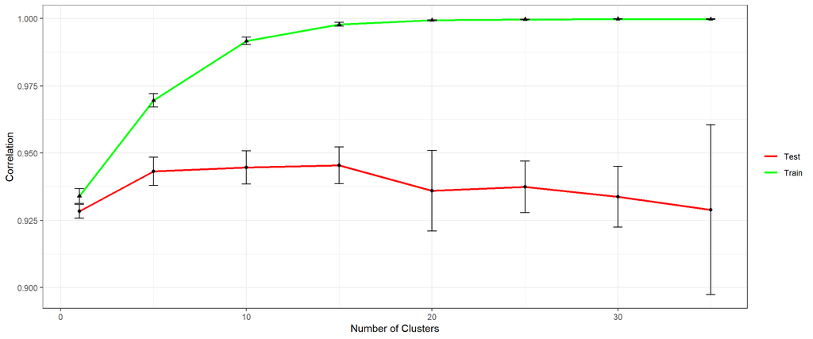

```r
plot.cv(cvCorrTrn, cvCorrTst, "Correlation")
```

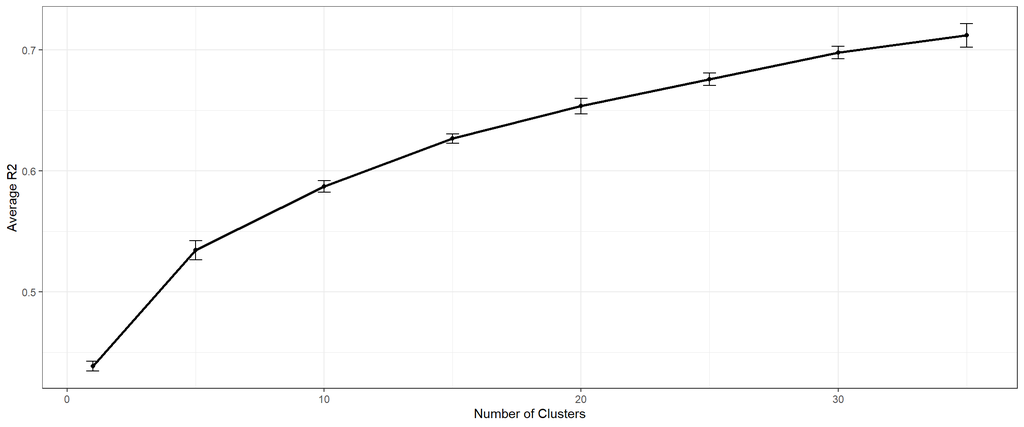

```r
toplotr2 <- data.frame(yt = colMeans(cvR2Trn),
                       et = apply(cvR2Trn, 2, sd),nc = nClusters)
ggplot(toplotr2) +
    geom_line(aes(x = nc, y = yt), size = 1) +
    geom_point(aes(x = nc, y = yt, shape = 'a'), show.legend = FALSE) +
    geom_errorbar(aes(x = nc,ymin = yt - et,ymax = yt + et), width = 0.5) +
    theme_bw() + xlab("Number of Clusters") + ylab("Average R2")
```

```r
rm(toplotr2, cvRmseTst, cvRmseTrn, cvCorrTrn, cvCorrTst, cvR2Trn)
```

# Appendix